# Práctica 4: Metaheurísticas basadas en poblaciones - Sistemas de Colonias de Hormigas

## Instrucciones

Esto es **Jupyter Notebook**, un documento que integra código Python en un archivo Markdown. Esto nos permite ir ejecutando celdas de código poco a poco, así como generar automáticamente un informe bien formateado de la práctica.

Puedes añadir una celda con el botón **"Insert"** de la barra de herramentas, y cambiar su tipo con **"Cell > Cell Type"**

Para ejecutar una celda de código, la seleccionaremos y pulsaremos el botón **"▶ Run"** de la barra de herramentas. Para pasar el documento a HTML, seleccionaremos **"File > Download as > HTML (.html)"**

Sigue este guión hasta el final. Ejecuta el código proporcionado paso a paso comprendiendo lo que estás haciendo y reflexionando sobre los resultados. Habrá preguntas intercaladas a lo largo del guión, responde a todas ellas en la sección reservada para ese fin: **"Respuestas a los cuestionarios"**. Por favor, no modifiques ninguna linea de código excepto cuando se te pida explícitamente.

No olvides insertar tu **nombre y apellidos** en la celda superior.

IMPORTANTE: Escribe el código de tu o tus soluciones/respuestas en las celdas que se indican para ello. Además, a lo largo de la práctica se plantearán varias preguntas que debéis responder en la parte inferior del documento, incluyendo las celdas que veáis necesarias (si hacéis referencia a partes concretas de vuestro código, etc) para reponder a ellas.

## Entrega de la práctica

La fecha límite de entrega será la indicada en el Campus Virtual. La entrega consistirá de un único archivo comprimido con nombre `APELIDOS_NOME_Colonias.zip` que contenga los seguientes ficheros:

- `APELIDOS_NOME_Colonias.html`: Archivo HTML fruto de la exportación del presente Notebook, con las preguntas respondidas al final del documento.
- `APELIDOS_NOME_Colonias.ipynb`: Archivo fuente Jupyter Notebook.
- Archivo de datos de los problema utilizados en la resolución.

## Preliminares adicionales sobre Python

Para esta práctica, te sugerimos algunas funciones de paquetes que pueden resultarte útiles en la realización de esta práctica.

Has visto que cuando realizas laboratorios y pruebas para ajustar parámetros resulta necesario tener una estimación del tiempo invertido en la ejecución. Eso ayuda a valorar el balance del tiempo computacional frente a la inclusión de valores de parámetros en el laboratorio. En ese sentido, puede resultar conveniente añadir barras de progreso que además te permitan visualizar el progreso de resolución de las iteraciones. Para ese propósito podéis hacer uso del paquete `tqdm` (https://tqdm.github.io/).

Puedes ver ejemplos en detalle descritos en https://towardsdatascience.com/progress-bars-for-python-with-tqdm-4dba0d4cb4c

Veámos un ejemplo ilustrativo aquí.

```python
# solo debes importarlo una vez en el notebook.
# fíjate que estamos importando del paquete tqdm.notebook para que incorpore los decoradores compatibles en Jupyter
# (en Python podrías importar simplemente desde el paquete tdqm)
from tqdm.notebook import trange, tqdm
```

`tqdm` permite añadir una barra de progreso que informe sobre el tiempo y el paso de iteraciones. En el ejemplo, la variable `nit` son el número de iteraciones a realizar y para conseguir que se visualize el progreso se pasa a `tqdm` un iterador de rango.

```python
from random import randint

heads = 0
tails = 0
nit=1000000
for i in tqdm(range(nit), desc='Coin Flip Progress'):
    toss = randint(0, 1)
    if toss == 0:
        heads += 1
    else:
        tails += 1
```

El paquete nos ofrece la posibilidad combinar `tdqm(range(NUM_IT))` en una única función, llamada `trange(NUM_IT)`. Veamos su funcionamiento en el siguiente ejemplo, que muestra también cómo podemos hacer cuando necesitamos llevar cuenta del progreso en bucles anidados.

```python
num_games = 3

for game in trange(num_games, desc='Overall Progress'):
    heads = 0
    tails = 0
    nit=1000000
    for j in trange((nit), desc=f'Game {game+1} Progress'):
        toss = randint(0, 1)
        if toss == 0:
            heads += 1
        else:
            tails += 1

    print(f'Heads: {heads}, Tails: {tails}')
```

```
Heads: 499263, Tails: 500737
```

```
Heads: 500484, Tails: 499516
```

```
Heads: 500080, Tails: 499920
```

## El Problema del Viajante de Comercio (VC) con Sistemas de Colonias de Hormigas

El objetivo de esta práctica es modelar e implementar un agente inteligente que sea capaz de resolver el problema del VC mediante la metaheurística (MH) de algoritmos para sistemas de colonias de hormigas (ACS, *Ant Colony Systems*, del inglés).

Para ello, realizarás una implementación del algoritmo básico visto en la clase expositiva y valorarás algunos de los parámetros de diseño del algoritmo en relación a la calidad de las soluciones alcanzadas.

Recuerda que debes importar el módulo Python que acompaña esta práctica, que como ocurría en prácticas anteriores implementa la carga de datos y el cálculo de distancias utilizando una matriz de adyacencia de acuerdo a la definición del problema ya vista.

```python
from helpers_mod_aco import *

g1 = Localizaciones(filename='./data/grafo8cidades.txt')
g2 = Localizaciones(filename='./data/US120.txt')

# distancia entre ciudad 0 y 1 son unos 55 km
print(g1.distancia(0,1))
print(g2.distancia(0,1))
```

```
55.88273580792048
1596.5471930797373
```

Se define una función para visualizar las ciudades y la solución.

```python
import matplotlib.pyplot as plt
import matplotlib.patches as mpatches

# Se define además una función que dibuja en un gráfico las ciudades y los caminos
def visualizar(loc, sol):
    fig = plt.figure()
    ax = fig.add_subplot(111, projection='rectilinear')
    ax.set_title("Camino")
    for i in range(0, loc.nciudades):
        ciudad = loc.tablaciudades[i][::-1]
        ax.plot(ciudad[0], ciudad[1], "or")
    for i in range(0, len(sol)-1):
        c1 = loc.tablaciudades[sol[i]][::-1]
        c2 = loc.tablaciudades[sol[i+1]][::-1]
        ax.plot([c1[0], c2[0]], [c1[1], c2[1]], 'k-', lw=2)
    if len(sol) > 0:
        c0 = loc.tablaciudades[0][::-1]
        c1 = loc.tablaciudades[sol[0]][::-1]
        c2 = loc.tablaciudades[sol[len(sol)-1]][::-1]
        ax.plot([c0[0], c1[0]], [c0[1], c1[1]], 'k-', lw=2)
        ax.plot([c2[0], c0[0]], [c2[1], c0[1]], 'k-', lw=2)
    plt.show()
```

## P4.1: Implementación de Sistemas de Colonias de Hormigas (SCH)

Implementa el algoritmo de sistemas de colonia de hormigas que materializa la MH vista en la sesión expositiva (diapositivas 33-36). Revisa las diapositivas 26-28 que ofrece algunas notas sobre el algoritmo de sistemas de hormigas particularizado al problema de VC. Para facilitar vuestra labor, se os proporciona aquí una descripción algorítmica para consulta.

1. Establecer parámetros: G, m, q<sub>0</sub>, τ<sub>0</sub>, ρ, 𝛏, iter<sub>min</sub>, iter<sub>max</sub>, iter<sub>sinmejoras</sub>, ratio<sub>mejora</sub>
2. Inicializar pistas de feromonas: ∀ i, j τ<sub>ij</sub> = τ<sub>0</sub>
3. HACER

   3.1. PARA cada hormiga k en colonia m HACER

   ```
    3.1.1.construir una solución para k siguiendo la regla de decisión a cada paso:
   ```

$$ j= \begin{cases} argmax_{l\in N_i^k} \{ [\tau_{il}]^\alpha [\eta_{il}]^\beta \}, \text{if } q \leq q_0;\\ J, \text{en otro caso;} \end{cases} $$

```
, donde J es la exploración dirigida por:
```

$$ p_{ij}^{k} = \frac{[\tau_{ij}]^\alpha [\eta_{ij}]^\beta}{\sum_{l\in N_i^k} [\tau_{il}]^\alpha [\eta_{il}]^\beta}, \text{if } j\in N_i^k $$

```
    3.1.2. (opcional) Aplicar actualización de feromona local/online con la regla:
```

$$ τ_{ij} ← (1 - 𝛏) τ_{ij} + 𝛏 τ_{0} $$

```
3.2. FPARA
3.3. (opcional) Aplicar métodos de búsqueda local

3.4. Evalúa soluciones en la colonia m y registrar la mejor solución hasta el momento: T bs

3.5. Aplicar actualización de feromona global/offline con la regla:
```

$$τ_{ij} ← (1-ρ) τ_{ij} + ρ Δτ_{ij}^{bs}, ∀(i, j) ∈T^{bs}$$

1. HASTA cumplir la condición de parada

La implementación debe permitir la inicialización de los parámetros y estructuras de información asociadas como sigue:

- Probabilidad de explotación q<sub>0</sub>=0.5.
- Inicialización de la información heurística: η<sub>ij</sub>=1/d<sub>ij</sub>, ∀(i, j), donde d<sub>ij</sub> es la distancia directa entre las ciudades *i* y *j*.
- Inicialización de las pistas de feromonas (depósito inicial): τ<sub>ij</sub>= τ<sub>0</sub>= 1 /(n C<sup>NN</sup>) ∀(i, j) donde n es el número de ciudades y C<sup>NN</sup> es el coste del tour generado siguiendo una estrategia voraz del vecino más próximo (NN, *Nearest Neighbour*).
- Parámetros de influencia de las pistas de feromonas (α) e información heurística (β) en la regla de decisión establecidos a 1 y 3 respectivamente
- Ratio de evaporación de feromona: deberás probar con diferentes magnitudes (p.ej., ρ=0.01, ρ=0.1 y ρ=0.5)
- Actualización de feromona global con depósito elitista basado en la mejor solución (bs, *best solution*): τ<sub>ij</sub> ← (1-ρ) τ<sub>ij</sub> + ρ Δτ<sub>ij</sub><sup>bs</sup>, ∀(i, j) ∈T<sup>bs</sup>, donde Δτ<sub>ij</sub><sup>bs</sup>=1/C<sup>bs</sup>
- Actualización de feromona local siguiendo la regla: τ<sub>ij</sub> ← (1- 𝛏) τ<sub>ij</sub> + 𝛏 τ<sub>0</sub>, con 𝛏=0.1
- Condición de parada que de manera combinada tenga en cuenta iter<sub>min</sub>, iter<sub>max</sub>, iter <sub>sinmejoras</sub>, ratio<sub>mejora</sub>
- La implementación debe ser completamente parametrizable, de forma que todos los componentes susceptibles de ser ajustados mediante parámetros deberían puedan ser establecidos en cada ejecución/problema, y que puedas modificar la inicialización heurística y de pistas de feromona, puedas fácilmente reemplazar las reglas de actualización de feromonas, activar/desactivar la actualización local de actualización de feromona, etc.

Prueba tu implementación tomando instancias de problemas que has utilizado en prácticas anteriores. Lanza varias ejecuciones para verificar que puede resolver el problema con los problemas de las 8 ciudades gallegas (`data/grafo8cidades.txt`) y de las 120 ciudades estadounidenses (`data/US120.txt`).

❓ **Pregunta 1**. Explica brevemente los detalles relevantes de tu código para entender tu implementación (p.ej., estructura de tu código, funciones, implementación de operadores, etc.). Explica también cómo has realizado la verificación de tu implementación.

```python
# Para esta práctica, se ha implementado el algoritmo en un archivo separado utilizando una clase, permitiendo así
# modular más el código y facilitar su uso.
# La clase que implementa el algoritmo es la clase Aco, y recibe como parámetro obligatorio un grafo, y como opcionales
# una condición y valor de parada.

from aco import Aco

# Además, de define la clase AcoParada, dando las opciones posibles para la parada del algoritmo.

from aco import AcoParada
psource(AcoParada)
```

```
class AcoParada:
    # Iteraciones mínimas del algoritmo, ignorando las máximas y sin mejora
    iter_min = None
    # Iteraciones máximas del algoritmo
    iter_max = None
    # Iteraciones máximas consecutivas en las que no se mejora
    iter_sinmejoras = None
    # Ratio
    ratio_mejora = None

    def __init__(self, iter_min=None, iter_max=1000, iter_sinmejoras=None, ratio_mejora=None):
        """
        Especifica las condiciones de parada del algoritmo. Se ha de especificar al menos las iteraciones máximas o
        las iteraciones sin mejorar.
        :param iter_min: número de iteraciones mínimas garantizadas, ignorando las iteraciones máximas y sin mejorar
        :param iter_max: número de iteraciones máximas del algoritmo, ignorando los ratios de mejora
        :param iter_sinmejoras: número de iteraciones máximas consecutivas sin mejorar
        :param ratio_mejora: ratio de mejora que, en caso de ser menor, no se considerará que una solución mejore
        """
        self.iter_min = iter_min
        self.iter_max = iter_max
        self.iter_sinmejoras = iter_sinmejoras
        self.ratio_mejora = ratio_mejora

        if self.iter_max is None and self.iter_sinmejoras is None:
            raise Exception("Se ha de especificar o las iteraciones máximas totales o las iteraciones sin mejorar")
        elif self.iter_sinmejoras is not None and self.ratio_mejora is None:
            self.ratio_mejora = 0
```

```python
# El constructor de la clase Aco toma es como se ve a continuación:
psource(Aco.__init__)

# Recibe el grafo con la condición de parada opcional (por defecto, tomará 1000 iteraciones máximas). Estos datos se
# almacenan en los atributos de la clase y se inicializan las matrices de distancias y feromonas.
```

```
    def __init__(self, grafo, parada=AcoParada(), leave=True):
        """
        Inicialización del algoritmo de Colonia de Hormigas.
        :param grafo: grafo sobre el que aplicar el algoritmo
        :param parada: condiciones para la detención del algoritmo
        :param leave: si se indica como False, se ocultará la barra de progreso al acabar
        """
        self.__g = grafo
        self.__parada = parada
        self.__leave = leave

        self.__t0 = None
        self.__nij, self.__tij = None, None
        self.__bs, self.__bsc = None, None

        self.__inicializar_nij()
        self.__inicializar_tij()
```

```python
# Para realizar el experimento, la clase Aco da un método solucion(), tal como se ve a continuación:
psource(Aco.solucion)

# Se almacenan en unas variables dos contadores de iteraciones y de iteraciones sin mejora. A continuación, se inicializa
# la barra de progreso, y se ejecuta el algoritmo en 3 pasos:
# 1. Calcular las soluciones que genera cada hormiga de la colonia.
# 2. Seleccionar la mejor solución, y calcular su ratio de mejora
# 3. Actualizar la feromona global

# Finalmente, se incrementa el contador de iteraciones sin mejora si el ratio de mejora es inferior o igual al especificado
# y se actualiza la barra de progreso.
# Y ya por último, en función de las condiciones de parada, se fuerza a seguir ejecutando el algoritmo si hay unas condiciones
# mínimas especificadas, o se detiene si se llegan a las máximas o a las máximas sin mejora.
```

```
    def solucion(self):
        """
        Se devuelve la solución del camino óptimo de un grafo mediante el algoritmo de colonias de hormigas.
        Dependiendo de la condición de parada, se llamará a una estructura del algoritmo u otra, siendo la por
        defecto la de un máximo de 1000 iteraciones. Además, al acabar de encontrar una solución, se resetean todas
        las matrices temporales, permitiendo ejecutarlo de nuevo cambiando los atributos públicos.
        :return: solución óptima encontrada
        """
        iters = 0
        iters_sinmejora = 0

        # Iniciar la abrra de progreso en función de la condición máxima de parada
        iters_max = None
        if self.__parada.iter_max is not None:
            iters_max = self.__parada.iter_max
        elif self.__parada.iter_sinmejoras is not None:
            iters_max = self.__parada.iter_sinmejoras
        pbar = tqdm(total=iters_max, leave=self.__leave)

        while True:
            if self.__parada.iter_max is not None:
                iters += 1
                pbar.update()

            # Se calculan las soluciones para cada hormiga
            sols = self.calcular_soluciones_k()

            # Se selecciona la mejor solución de las encontradas, incluyendo la actual
            bs, bsc = self.seleccionar_mejor_solucion(sols)
            # Y se calcula el ratio de mejora con respecto a la anterior, actualizando la global tras esto
            if self.__bs is None:
                ratio_mejora = 1
            else:
                ratio_mejora = 1 - (bsc / self.__bsc)
            self.__bs, self.__bsc = bs, bsc

            # Se actualiza la feromona en base a esta solución encontrada
            self.actualizar_feromona_global()

            # Si se especifica una condición de parada de iteraciones sin mejora, resetear el contador si el ratio
```

[output cut: 17 more lines]

```
            if self.__parada.iter_max is not None and iters >= self.__parada.iter_max:
                break
        # Cerrar la barra de progreso, forzando el completado
        if self.__parada.iter_sinmejoras is not None and pbar.n < pbar.total:
            pbar.update(pbar.total - pbar.n)
        pbar.close()

        # Almacenar la solución actual en una tupla
        sol = self.__bs, self.__bsc

        # Resetear las matrices de cálculo y la solución obtenida
        self.__init__(self.__g, self.__parada, self.__leave)

        # Devolver la solución
        return sol
```

```python
# Ahora, veamos el cálculo de las soluciones para cada hormiga:
psource(Aco.calcular_soluciones_k)

# Como se puede apreciar, para cada hormiga, se mantiene una lista de ciudades pendientes por visitar, y,
# para cada una de ellas, dependiendo de la aleatoriedad se escoge la siguiente ciudad mediante explotación
# o mediante exploración dirigida.
```

```
    def calcular_soluciones_k(self):
        """
        Para cada hormiga de la colonia, se calcula una solución válida. Para esto, hay dos opciones de calcular los
        nodos siguientes: mediante exploración dirigida o explotación. Esto se hace de manera aleatoria, con una
        probabilidad dada por el atributo q0.
        :return: lista de soluciones, una por hormiga
        """
        sols = []
        for k in range(self.m):
            sol = [0]
            # Para cada hormiga, se almacena en una lista las ciudades pendientes de visitar
            disponibles = list(range(1, self.__g.nciudades))
            # Se itera mientras queden ciudades por visitar
            while len(disponibles) > 0:
                # La ciudad i será la última visitada
                i = sol[len(sol) - 1]
                q = random.uniform(0, 1)
                # En función de un valor aleatorio, se decide que la ciudad a visitar j será extraida por
                # explotación o por exploración dirigida
                if q < self.q0:
                    j = self.explotacion(disponibles, i)
                else:
                    j = self.exploracion_dirigida(disponibles, i)
                # Se inserta el elemento en la solución de la hormiga y se elimina de las disponibles
                sol.append(j)
                disponibles.remove(j)
            # Se guarda la solución en la lista de soluciones, una por hormiga
            sols.append(sol + [0])
        return sols
```

```python
# Se muestran ahora ambos métodos para averiguar la ciudad siguiente:

psource(Aco.explotacion)
psource(Aco.exploracion_dirigida)
```

```
    def explotacion(self, disponibles, i):
        """
        En la asignación de caminos, la explotación consiste en realizar una búsqueda local para encontrar
        el mejor camino. Se tiene en cuenta la distancia y la feromona, pero sólo se tendrá en cuenta cual es el
        próximo mejor en base a esos dos parámetros.
        :param disponibles: ciudades pendientes de visitar
        :param i: ciudad actual
        :return: ciudad que se ha de visitar
        """
        opciones = []
        for l in disponibles:
            # Para cada ciudad disponible, almacenar un valor indicando feromona y distancia
            opciones.append((l, (self.__tij[i][l] ** self.alpha) * (self.__nij[i][l] ** self.beta)))
        opciones = sorted(opciones, key=lambda o: o[1])
        # Se devuelve la ciudad cuyo valor sea el más alto
        j = opciones[len(opciones) - 1][0]
        return j
```

```
    def exploracion_dirigida(self, disponibles, i):
        """
        En la asignación de caminos, esta función devolverá el siguiente nodo para una hormiga dada utilizando
        exploración dirigda. Esta consiste en asignar unas proabilidades, y en base a una distribución ordenada,
        decidir de manera aleatoria por probabilidad a cual se avanza.
        :param disponibles: ciudades pendientes por visitar
        :param i: ciudad actual
        :return: ciudad a visitar a continuación
        """

        # Se calcula la suma de todas las probabilidades
        s = sum((self.__tij[i][l] ** self.alpha) * (self.__nij[i][l] ** self.beta) for l in disponibles)
        opciones = []
        for l in disponibles:
            # Para cada opción, calcular su probabilidad divida por la total
            opciones.append((l, ((self.__tij[i][l] ** self.alpha) * (self.__nij[i][l] ** self.beta)) / s))
        # Se ordena las soluciones por probabilidad de mayor a menor
        opciones = sorted(opciones, key=lambda o: 1 / o[1])

        # Se genera un número aleatorio de "corte"
        m = random.uniform(0, 1)
        j, agregado = None, 0
        for opcion in opciones:
            # Se suma la probabilidad agregada, y se almacena la ciudad a visitar
            agregado += opcion[1]
            j = opcion[0]
            # Si la suma agregada es mayor que el corte, se para de iterar y se devuelve la ciudad encontrada
            if agregado >= m:
                break
        return j
```

```python
# Ahora, una vez calcular_soluciones_k devuelve una lista de soluciones (una por hormiga),
# hay que escoger la mejor de ellas. Por ello, la función siguiente hace tal tarea:
psource(Aco.seleccionar_mejor_solucion)

# Se puede ver como también se tiene en cuenta la mejor solución global, ya que si ninguna hormiga
# ha mejorado, entonces se mantiene la misma solución global (salvo en la primera iteración, que al
# no haber ninguna se tomará la mejor de las hormigas).
```

```
    def seleccionar_mejor_solucion(self, sols):
        """
        Dada una lista de soluciones obtenidas por el algoritmo, se extrae la mejor en función de su coste. Se
        tiene en cuenta también la mejor solución global, por lo que es posible que se devuelva la misma solución
        global.
        :param sols: lista de soluciones
        :return: mejor solución, incluyendo en el cálculo la global
        """
        mejor_solucion, mejor_coste = None, None
        for sol in sols:
            coste = self.__coste(sol)
            # Si se mejora el coste con respecto a otras soluciones locales, guardar como mejor solución local
            if mejor_solucion is None or coste < mejor_coste:
                mejor_solucion, mejor_coste = sol, coste

        # Si se mejora el coste de la mejor solución global, devolver la nueva
        if self.__bs is None or mejor_coste < self.__bsc:
            return mejor_solucion, mejor_coste
        # Sino, devolver la global
        return self.__bs, self.__bsc
```

```python
# Del paso anterior se devuelve tanto el coste como la solución, por lo que en el método solucion()
# se actualizan estos atributos que almacenan las mejores soluciones.

# Finalmente, se actualiza la matriz de feromonas en base a esta solución obtenida con el siguiente
# método:
psource(Aco.actualizar_feromona_global)
```

```
    def actualizar_feromona_global(self):
        """
        Cogiendo la mejor solución global, se aplica la fórmula de actualización de feromonas a los caminos
        visitados por esta solución (sólo de ida, no en ida y vuelta ya que los caminos tienen solución). El
        resultado se almacena en la matriz de feromonas.
        """
        for k in range(1, len(self.__bs)):
            i, j = self.__bs[k - 1], self.__bs[k]
            self.__tij[i][j] = (1 - self.p) * self.__tij[i][j] + self.p * (1 / self.__bsc)
```

```
381.6699617675482
```

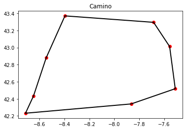

```python
# Y la puesta en práctica del algoritmo:

a1 = Aco(g1, parada=AcoParada(iter_max=500))
sol1, coste1 = a1.solucion()
print(coste1)
visualizar(g1, sol1)
```

```
24591.99909265263
```

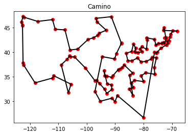

```python
# Y ahora el archivo US120.txt:

a2 = Aco(g2, parada=AcoParada(iter_max=1000, iter_sinmejoras=20, ratio_mejora=1/1000), leave=None)
sol2, coste2 = a2.solucion()
print(coste2)
visualizar(g2, sol2)
```